# Summary of the project

From the data provided (stock history, column B) in the file *Dataset*, we want to create the portfolio history replication of a European call with maturity on **31/12/2018**, strike **K = 6**. To do that, we are going to use a synthetic replication portfolio formed from a stock, cash and another K6.5 European call option (to neutralize the effect of gamma on the delta of the option)

Overview of the data

```
##          Date Prix.action Prix.option.strike.6 Prix.option.strike.6.5
## 1  02/10/2017       6.742                   NA                     NA
## 2  03/10/2017       6.955                   NA                     NA
## 3  04/10/2017       6.910              1.02096                0.59093
## 4  05/10/2017       7.006              1.09932                0.65885
## 5  06/10/2017       7.000              1.09306                0.65440
## 6  09/10/2017       6.950              1.04813                0.61591
## 7  10/10/2017       6.856              0.96879                0.54811
## 8  11/10/2017       6.795              0.91992                0.51253
## 9  12/10/2017       6.744              0.88119                0.49517
## 10 13/10/2017       6.561              0.74526                0.41163
```

# I. Introduction

Let’s assume here that $\sigma_{cte} = 20$%. Let’s compute now the vector of maturity thanks to the following formula $T_i = \frac{(T_{mat} - t_i)}{365}$.

Overview of the vector of maturities

```
##  [1] 1.246575 1.243836 1.241096 1.238356 1.235616 1.227397 1.224658 1.221918
##  [9] 1.219178 1.216438
```

Then, we are going to use the **Black-Scholes formula** to price the corresponding european option call Black-Scholes formula : $C(S, t) = S_tN(d_2) - e^{-r(T - t)}KN(d_2)$ with $r = 0$, $\sigma = 20$% and $K = 6$

Overview of the K6 call option value (target) over time

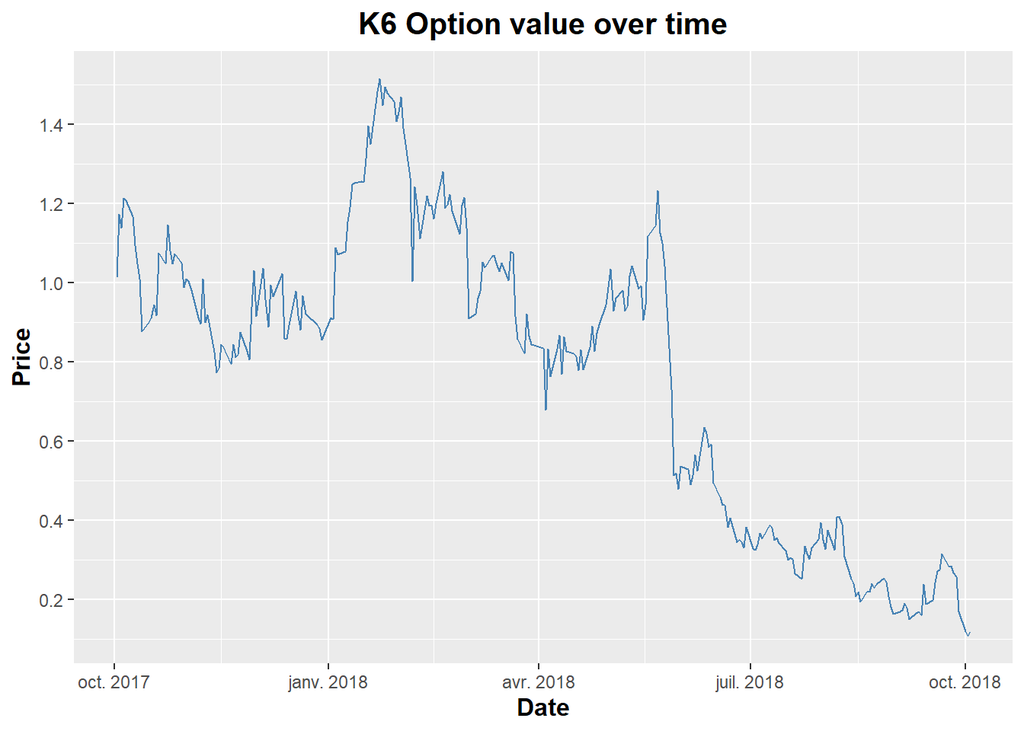

Now, let’s visualize the value of the second call option (strike K6.5)

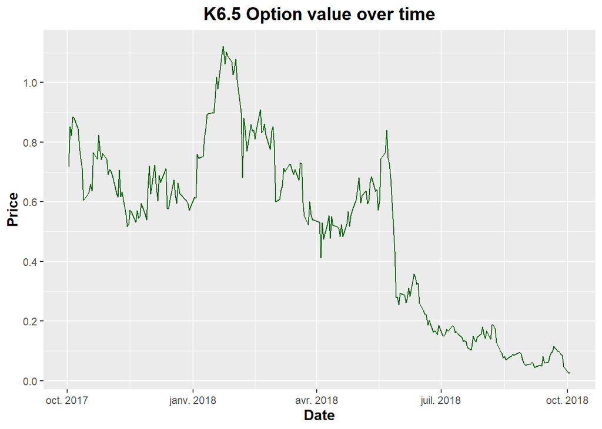

# II. Delta-Gamma hedged portfolio with constant volatility

In this part, we are going to build a synthetic delta-Gamma hedged portfolio **formed by a stock, cash and a K6.5 call option**. The value of the portfolio **must be equal to the value of the option** to be replicated.

Overview of the principles of **delta-gamma hedging** :

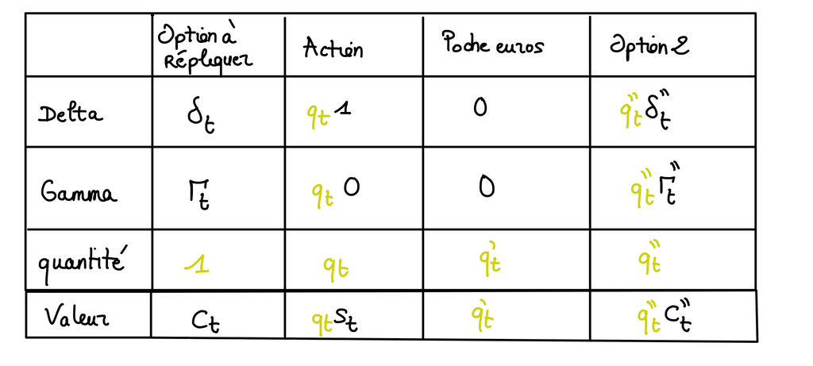

Here, **we have three parameters** : $q, q'$ and $q''$ corresponding to the quantities of stock, cash and K6.5 option. We have to solve the following linear system to find the value of $q, q'$ and $q''$ :

$$\left\{
\begin{array}{l}
q_t + q''_t\delta''_t = \delta_t\qquad (1) \\
q''_t = \frac{\Gamma_t}{\Gamma''_t}\qquad (2)\\
q_tS_t + q'_t + q''_tC''_t = C_t\qquad (3)
\end{array}
\right.$$
$$\left\{
\begin{array}{l}
q_t = \delta_t - q''_t\delta''_t\qquad (1)\\
q''_t = \frac{\Gamma_t}{\Gamma''_t}\qquad (2) \\
q'_t = C_t - q''_tC''_t - q_tS_t\qquad (3)
\end{array}
\right.$$
Overview of the iteration process :

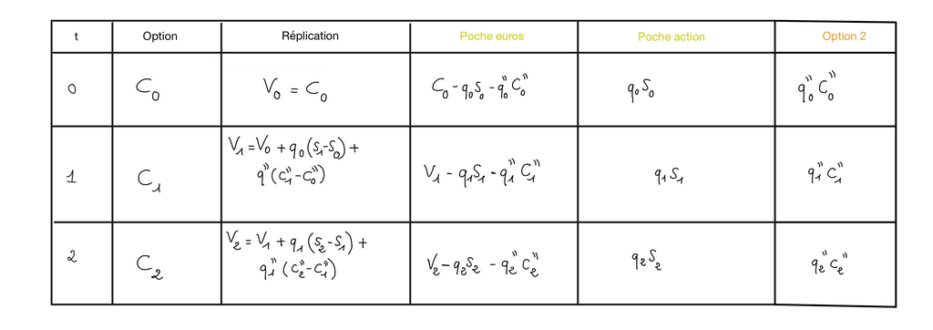

Here, $\delta_t = N\big(d_1(t)\big)$ with $d_1(t) = \frac{1}{\sigma\sqrt{T_t}}\Big[ln\big(\frac{S_t}{K}\big) + \big(r + \frac{1}{2}\sigma^2\big)T_t\Big]$, $S_t$ the value of the stock and $T_t$ the vector of maturities. Furthermore, we have $\Gamma_t = \frac{N'(d_1)}{S\sigma\sqrt{T}}$,

We can deduce the **general formula** to obtain the value of the portfolio over time :

$V_t = V_{t - 1} + q_{t - 1}(S_t - S_{t - 1}) + q''_{t - 1}(C''_t - C''_{t - 1})$

Now, let’s compute the value of $\delta_t$ and $\Gamma_t$ over time and give an overview of them.

```
##  [1] 0.7368957 0.7804467 0.7719176 0.7903820 0.7894580 0.7805751 0.7621479
##  [8] 0.7496394 0.7388317 0.6968998
```

```
##  [1] 0.2167716 0.1906398 0.1962999 0.1846325 0.1854742 0.1919857 0.2038638
##  [8] 0.2116964 0.2183009 0.2413566
```

We do the same thing for $\delta'_t$ and $\Gamma'_t$ over time.

```
##  [1] 0.6084767 0.6608759 0.6502269 0.6729618 0.6716604 0.6601580 0.6374242
##  [8] 0.6222151 0.6092211 0.5606582
```

```
##  [1] 0.2551340 0.2359551 0.2405229 0.2314111 0.2322393 0.2378938 0.2471499
##  [8] 0.2530031 0.2577701 0.2724619
```

Here we are, we are going to use the previous iteration method mentioned above to build the portfolio history replication of the K6 option.

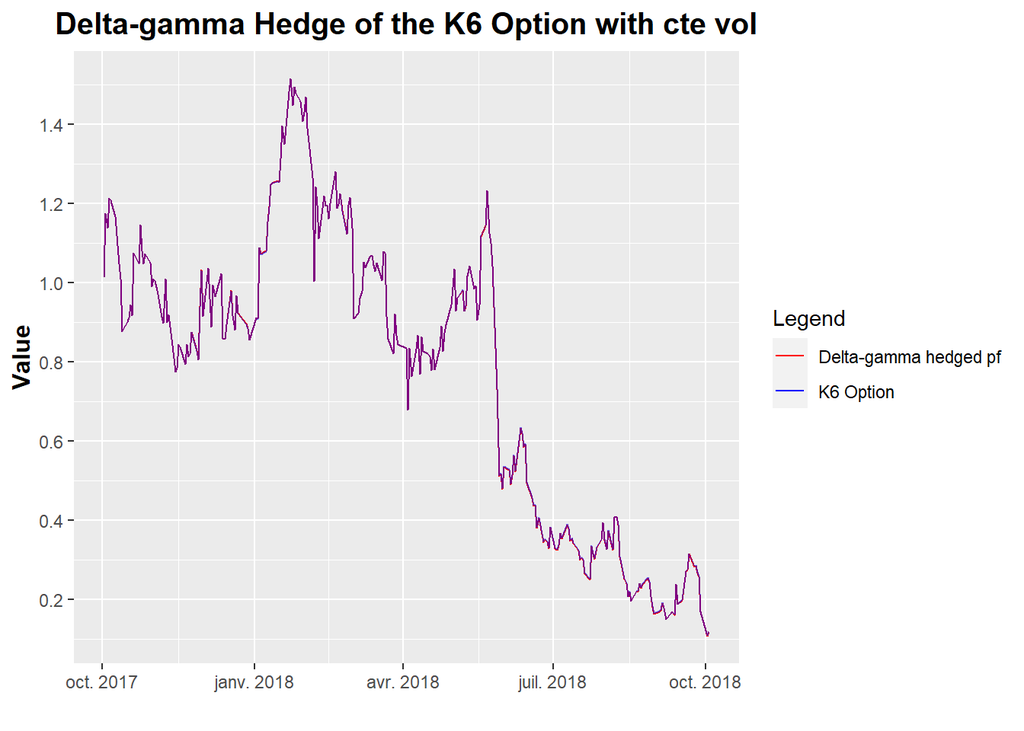

**Interpretation** : As we can see on the chart above, the two times series are almost equal over time. We can deduce that the hedge method is really efficient.

# III. Delta-Gamma hedged portfolio whith non-constant volatility

## III.I Calibration

1. Newton-Raphson’s algorithm To sum up, we are going to initialize a choosen value of and use the following iteration process : $\sigma_{i + 1} = \sigma_i - \frac{C_{market} - C^{BS}(\sigma)}{\frac{\partial C^{BS}}{\partial \sigma}}$ with $\frac{\partial C^{BS}}{\partial \sigma} = S\sqrt{T}N'(d_1)$

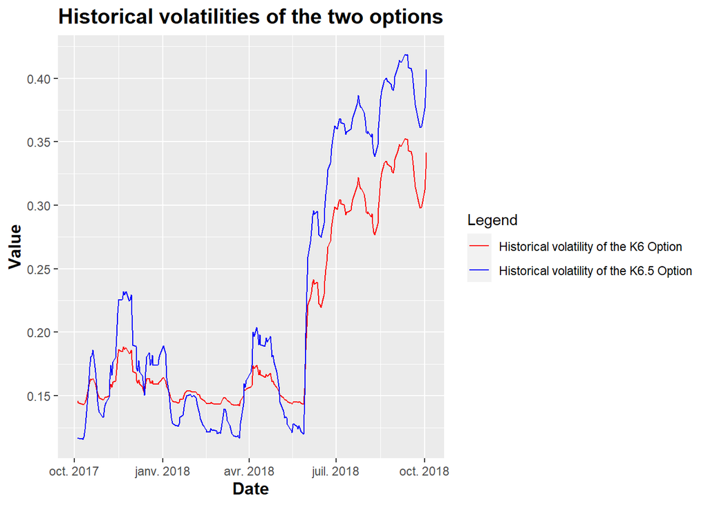

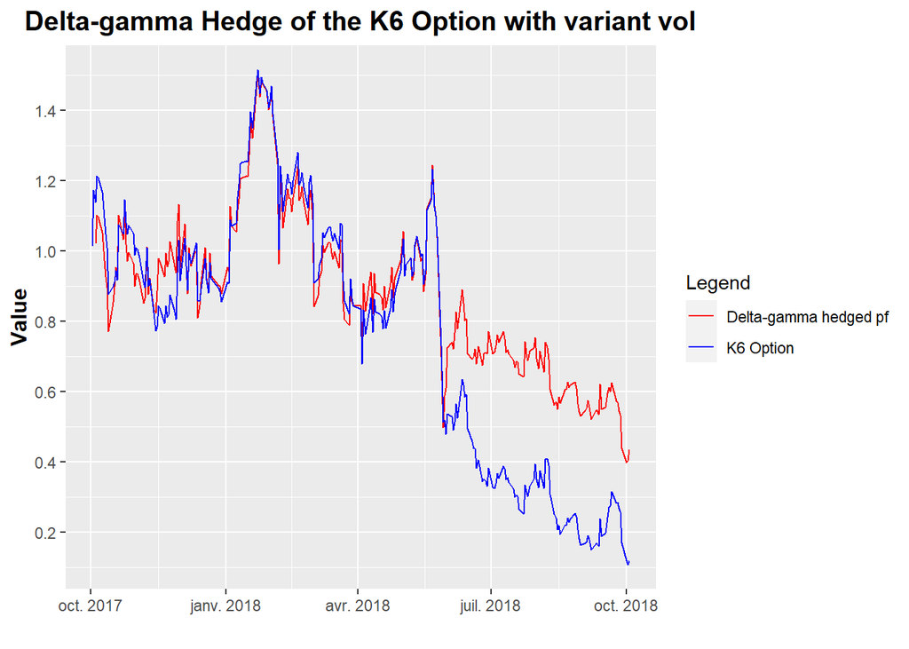